# POLISCI 9590 - Lab3: Reshaping Data

William Poirier

2024-10-01

## 000. What we’ll be doing

0. Review of last week’s exercise
1. Review of data cleaning
2. Reshaping data
3. From wide to long
4. From long to wide
5. Exercise

## 00. Last week’s exercise

From the `carData::Salaries` data set of 2008-2009 nine-month academic salary for Assistant Professors, Associate Professors and Professors in a college in the U.S., create a graph that presents:

1. The mean salary per years since PhD with regards to sex per discipline.
2. Make sure that the axis, facets and legend are properly named.
3. Rescale the y axis to have salaries in increments of 25000 and the x axis to have years in increments of 5.
4. Make sure the legend is on top of the graph.

```r
library(tidyverse)
range(carData::Salaries$yrs.since.phd)
```

```
## [1]  1 56
```

```r
range(carData::Salaries$salary)
```

```
## [1]  57800 231545
```

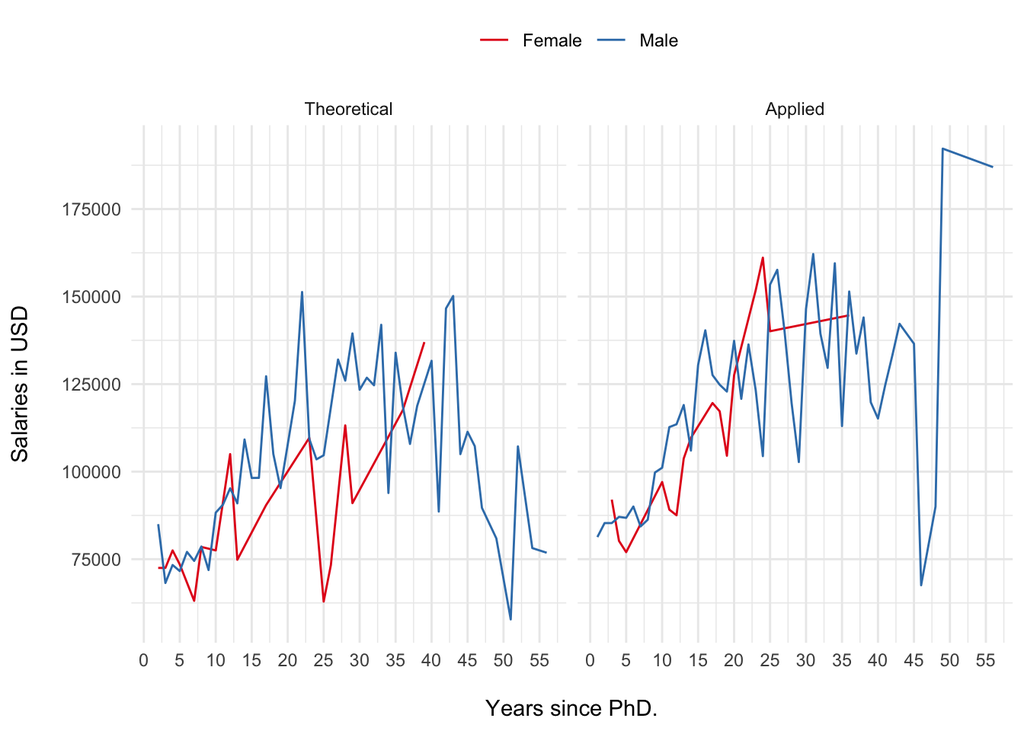

```r
carData::Salaries |>
  mutate(discipline=factor(discipline,
                           levels=c("A","B"),
                           labels=c("Theoretical","Applied"))) |>
  group_by(yrs.since.phd,sex,discipline) |>
  summarise(meanSal=mean(salary)) |>
  ggplot(aes(x=yrs.since.phd,y=meanSal,color=sex))+
  geom_line()+
  scale_x_continuous("\nYears since PhD.",breaks=seq(0,56,5))+
  scale_y_continuous("Salaries in USD\n",breaks=seq(0,250000,25000))+
  scale_color_brewer("",palette = "Set1")+
  facet_wrap(~discipline)+
  theme_minimal()+
  theme(legend.position = "top")
```

## 0. Data Cleaning

```r
## Setting up
library(rio)
setwd(dirname(rstudioapi::getActiveDocumentContext()$path))
CES_raw <- import("2021 Canadian Election Study v2.0.dta")

## A function to replace -99 by NA
remove99 <- function(x){
  out <- ifelse(x==-99,NA,x)
  return(out)
}

## Cleaning
CES <- factorize(CES_raw) |>
  rename(UUID=cps21_ResponseId,
         yob=cps21_yob,
         gender=cps21_genderid,
         prov=cps21_province,
         vote=pes21_votechoice2021,
         pplFeel_Americans=cps21_groups_therm_7,
         pplFeel_Francophones=cps21_groups_therm_3,
         pplFeel_LPC=cps21_party_rating_23,
         pplFeel_CPC=cps21_party_rating_24,
         pplFeel_NDP=cps21_party_rating_25,
         pplFeel_BQ=cps21_party_rating_26,
         pplFeel_GPC=cps21_party_rating_27,
         pplFeel_PPC=cps21_party_rating_29) |>
  select(UUID,yob,gender,prov,vote,
         pplFeel_Americans,pplFeel_Francophones,
         pplFeel_LPC,pplFeel_CPC,pplFeel_NDP,
         pplFeel_BQ,pplFeel_GPC,pplFeel_PPC) |>
  filter(!(prov %in% c("Northwest Territories","Nunavut","Yukon"))) |>
  mutate(age=2021-as.numeric(as.character(yob)),
         vt = case_when(
              vote == "Liberal Party" ~ "LPC",
              vote == "Conservative Party" ~ "CPC",
              vote == "ndp" ~ "NDP",
              vote == "Bloc Québécois" ~ "BQ",
              vote == "Green Party" ~ "GPC",
              vote == "People's Party" ~ "PPC",
              vote == "Another party (specify)" ~ "Other",
              vote %in% c("I spoiled my vote","Don't know / Prefer not to answer") ~ NA_character_
            ),
         prov=factor(prov,levels=c("British Columbia","Alberta","Saskatchewan","Manitoba",
                                   "Ontario","Quebec",
                                   "New Brunswick","Prince Edward Island","Nova Scotia",
                                   "Newfoundland and Labrador"))) |>
  mutate_at(vars(starts_with("pplFeel")),remove99)
```

## 1. Reshaping data, the idea

- **Wide** data: Each unit of analysis is found ONCE in the ID column.
- **Long** data: The units of analysis are repeated in the ID column.
- Going from wide to long: `tidyr::pivot_longer()`
- Going from long to wide: `tidyr::pivot_wider()`

Wide: Each unit of analysis is found ONCE in the ID column

| religion | $10-40k | $40-100k | >100k |
| --- | --- | --- | --- |
| Atheist | 116.00 | 178.00 | 133.00 |
| Catholic | 2019.00 | 2703.00 | 1425.00 |
| Evangelical Prot | 2915.00 | 3316.00 | 1137.00 |

Long: The units of analysis are repeated in the ID column

| religion | salary | n |
| --- | --- | --- |
| Atheist | $10-40k | 116.00 |
| Atheist | $40-100k | 178.00 |
| Atheist | >100k | 133.00 |
| Catholic | $10-40k | 2019.00 |
| Catholic | $40-100k | 2703.00 |
| Catholic | >100k | 1425.00 |
| Evangelical Prot | $10-40k | 2915.00 |
| Evangelical Prot | $40-100k | 3316.00 |
| Evangelical Prot | >100k | 1137.00 |

## 2. From wide to long

Using the `CES` data, create a graph that superimposes the histogram of feelings towards Francophones on top of the histogram of feelings towards Americans.

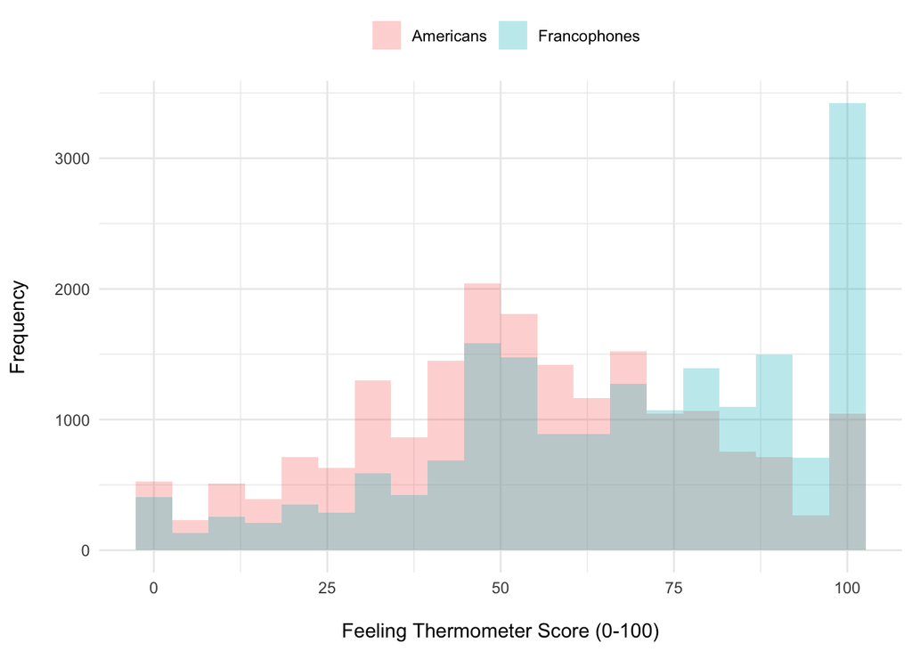

```r
Long <- CES |>
  pivot_longer(c("pplFeel_Americans","pplFeel_Francophones"),
               names_pattern = "pplFeel_(.*)",
               names_to = "group",values_to = "score")

ggplot(Long,aes(x=score,fill=group))+
  geom_histogram(position="identity",bins = 20,alpha=0.3)+
  theme_minimal()+
  theme(legend.position = "top")+
  labs(x="\nFeeling Thermometer Score (0-100)",
       y="Frequency\n",
       fill="")
```

### 2.1 Looking under the hood

Let’s do the same exercise, but without the help of `pivot_longer`.

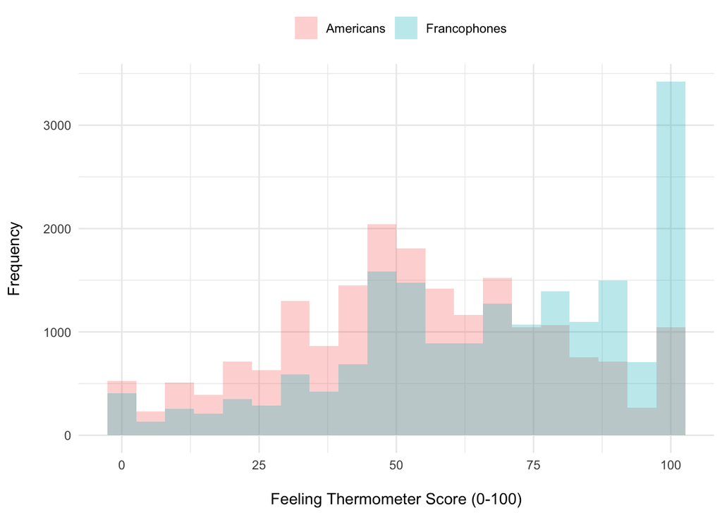

```r
Data_A <- CES |>
  select(-pplFeel_Francophones) |>
  rename(score=pplFeel_Americans) |>
  mutate(group="Americans")

Data_F <- CES |>
  select(-pplFeel_Americans) |>
  rename(score=pplFeel_Francophones) |>
  mutate(group="Francophones")

Long2 <- rbind(Data_A,Data_F)

ggplot(Long2,aes(x=score,fill=group))+
  geom_histogram(position="identity",bins = 20,alpha=0.3)+
  theme_minimal()+
  theme(legend.position = "top")+
  labs(x="\nFeeling Thermometer Score (0-100)",
       y="Frequency\n",
       fill="")
```

## 3. From long to wide

From `Long`, go back to the original data.

```r
Wide <- Long |>
  pivot_wider(names_from = "group", names_prefix = "pplFeel_",values_from = score)
```

### 3.1 Looking under the hood

From `Long` to the original data without the use of `pivot_wider`.

```r
Wide2 <- Long2 |>
  filter(group=="Americans") |>
  rename(pplFeel_Americans=score) |>
  mutate(pplFeel_Francophones=Long$score[Long$group=="Francophones"]) |>
  select(-group)
```

## 4. Exercise

Using the data we just cleaned (`CES`):

1. Compute the average score given to each party per province.
2. Present these averages in a graph where the Y axis are the provinces and the X axis the averages.